# Análisis introductorio de cambio en series de tiempo

Con datos de Landsat

## Introducción

El análisis de cambio en cobertura del suelo en series de tiempo corresponde a la detección de cambios en el tiempo de cobertura de forma consistente. Si una cobertura cambia una fecha, en lo sucesivo, ese cambio debe generar un patrón. Existen múltiples algoritmos para detectar cambios de cobertura empleando series de tiempo de Landsat, tal como está descrito en las referencias bibliográficas

Los diagramas de clima son útiles para identificar las fechas del año en que pueden existir cambios debidos a otros fenómenos diferentes a la preciptación. Por ello se usan los climadiagramas, o climogramas.

## Serie de tiempo LANDSAT

### 1. Carga de librerías

```python
import os, ee, geemap, geopandas as gpd
import pandas as pd, numpy as np, seaborn as sns
from zipfile import ZipFile
Map = geemap.Map()
Map.addLayerControl()
```

To authorize access needed by Earth Engine, open the following URL in a web browser and follow the instructions:

The authorization workflow will generate a code, which you should paste in the box below.

```
Enter verification code: 4/1AWgavdf9hf2-vBp6kL8eVMnmRQNh93IIv5lFNCf5cAAC1iFztksix-S_gV0

Successfully saved authorization token.
```

### 2. Lectura de datos

```python
shp1 = 'E:/CURSO_ANDES/Series_Tiempo/Datos_entrada/Cuencas/Apanas/CuencaApanas.shp'
pol1 = geemap.shp_to_ee(shp1)

zona = pol1.geometry().bounds()

shp2 = 'E:/CURSO_ANDES/Series_Tiempo/Datos_entrada/Cuencas/Apanas/ApanasPts5km.shp'
pts2 = geemap.shp_to_ee(shp2)
```

### 3. Despliegue

```python
Map.addLayer(zona, {}, 'Zona de estudio')
Map.addLayer(pol1, {}, 'Cuenca Apanás')
Map.addLayer(pts2, {}, 'Apanás puntos a 5 km')

Map.centerObject(zona)

Map.add_labels(
    pts2,
    "id",
    font_size="18pt",
    font_color="white",
    font_family="arial",
    # font_weight="bold",
)
```

```python
Map
```

```
Map(center=[13.162338952053695, -85.97019911626964], controls=(WidgetControl(options=['position', 'transparent…
```

### 4. Períodos secos y húmedos en el año

**Climogramas**

[output not shown]

### 5. Creación de serie de tiempo

```python
inicio  = 1985
termina = 2022
landsat_ts = geemap.landsat_timeseries(
    roi=zona, start_year=inicio, end_year=termina,
    start_date='01-01', end_date='12-31'
)
nombres = ['Landsat ' + str(year) for year in range(inicio, termina+1)]
print(nombres)
```

```
['Landsat 1985', 'Landsat 1986', 'Landsat 1987', 'Landsat 1988', 'Landsat 1989', 'Landsat 1990', 'Landsat 1991', 'Landsat 1992', 'Landsat 1993', 'Landsat 1994', 'Landsat 1995', 'Landsat 1996', 'Landsat 1997', 'Landsat 1998', 'Landsat 1999', 'Landsat 2000', 'Landsat 2001', 'Landsat 2002', 'Landsat 20…
```

### 6. Inspección de serie de tiempo

```python
landsat_vis = {
    'min': 0,
    'max': 0.5,
    'gamma': [1, 1, 1],
    'bands': ['NIR', 'Red', 'Green'],
}
```

En la siguiente gráfica se observa a la derecha una fecha y a la izquierda otra.

Cada lado tiene su lista de escenas a seleccionar por fecha.

Al centro se encuentra un deslizador que permite arropar una fecha con la otra para apreciar los cambios

```python
Map2 = geemap.Map()
Map2.ts_inspector(
    left_ts=landsat_ts,
    right_ts=landsat_ts,
    left_names=nombres,
    right_names=nombres,
    left_vis=landsat_vis,
    right_vis=landsat_vis,
)
Map2.addLayerControl()
Map2.centerObject(zona)
Map2
```

```
Map(center=[20, 0], controls=(WidgetControl(options=['position', 'transparent_bg'], widget=Dropdown(layout=Lay…
```

### 7. Generación de animación

```python
# Directorio de salida
out_dir = os.path.join('E:/CURSO_ANDES/Series_Tiempo/Productos')

if not os.path.exists(out_dir):
    os.makedirs(out_dir)

Map3 = geemap.Map()
label = 'Serie de tiempo Landsat en Apanás'
out_gif = 'E:/CURSO_ANDES/Series_Tiempo/Productos/Apanas.gif'
Map3.add_landsat_ts_gif(
    roi=zona,
    label=label,
    start_year=inicio,
    bands=['NIR', 'Red', 'Green'],
    font_color='white',
    frames_per_second=2,
    progress_bar_color='blue',
    out_gif = out_gif,
    dimensions=600,
    font_size=20,
)
```

```
Generating URL...
Downloading GIF image from https://earthengine.googleapis.com/v1alpha/projects/earthengine-legacy/videoThumbnails/875929ef09a590f5d0c05362b7c05a4e-bc058c62adecf3f6fe830485a7186e81:getPixels
Please wait ...
The GIF image has been saved to: E:\CURSO_ANDES\Series_Tiempo\Productos\Apanas.gif
Adding GIF to the map ...
The timelapse has been added to the map.
```

### 8. Despliegue de la animación

```python
Map3.centerObject(zona)
Map3
```

```
Map(center=[20, 0], controls=(WidgetControl(options=['position', 'transparent_bg'], widget=HBox(children=(Togg…
```

En este paso se recomienda:

- Observar los puntos en un SIG
- Aplicar técnicas de despliegue (mapas de calor) con las que pueda seleccionar los puntos que tengan mayor cambio en la cobertura bajo estudio
- Seleccionar 1 punto para la siguiente parte del análisis

# Análisis de un punto

Exportar los valores de las bandas para toda la serie de tiempo en el punto seleccionado

### 9. Punto seleccionado

```python
puntoSeleccionado = 19 # 12, 18, 11
```

Características espaciales del punto

```python
p = pts2.filter( ee.Filter.eq('id', puntoSeleccionado) ).first().getInfo()
x = p['geometry']['coordinates'][0]
y = p['geometry']['coordinates'][1]
print(p)
print(x,y)
```

```
{'type': 'Feature', 'geometry': {'type': 'Point', 'coordinates': [-86.01803928745473, 13.139205722913477]}, 'id': '18', 'properties': {'bottom': 1457737.3756, 'id': 19, 'left': 606430.1984, 'right': 611430.1984, 'top': 1452737.3756}}
-86.01803928745473 13.139205722913477
```

### 10. Nombres de las bandas

```python
bandas = landsat_ts.first().bandNames().getInfo()
print(bandas)
```

```
['Blue', 'Green', 'Red', 'NIR', 'SWIR1', 'SWIR2']
```

### 11. Renombrado de las bandas (traducción)

Para las figuras

También se crea el archivo csv para la tabla de datos por banda

```python
bandas = ['Azul', 'Verde', 'Rojo', 'IR Cercano', 'IR Onda Corta1', 'IR Onda Corta2']

# Extract zonal statistics per point per image.
out_landsat_stats = os.path.join(out_dir, 'Apanas_landsat_stats.csv')
# out_landsat_stats = os.path.join(out_dir, 'landsat_stats.kmz')  # Quitar marca de comentario y obtiene kmz
```

### 12. Generación de valores de bandas por año

```python
ptsLandsatStats = geemap.zonal_statistics(
    landsat_ts,
    pts2.filter( ee.Filter.eq('id', puntoSeleccionado) ),
    out_landsat_stats,
    statistics_type='MEAN',
    scale=10);
geemap.create_download_link(out_landsat_stats)
```

```
Computing statistics ...
Generating URL ...
Downloading data from https://earthengine.googleapis.com/v1alpha/projects/earthengine-legacy/tables/a674fd274e266fde134d875ee65676f1-fd1860570041c8ebebce17442d6f2c63:getFeatures
Please wait ...
Data downloaded to E:\CURSO_ANDES\Series_Tiempo\Productos\Apanas_landsat_stats.csv
```

Click here to download: Apanas_landsat_stats.csv

Lectura de kmz

```python
# import fiona
# fiona.drvsupport.supported_drivers['kml'] = 'rw' # enable KML support
# fiona.drvsupport.supported_drivers['KML'] = 'rw'
# kmz = ZipFile(out_landsat_stats, 'r')
# kmz.extract('landsat_stats.kml', './productos')

# gdf = gpd.read_file(
#   os.path.join('./productos','landsat_stats.kml'),
#   driver='KML')
```

### 13. Lectura de csv

```python
lst = pd.read_csv(out_landsat_stats)

col = lst.columns[-6:].tolist()
print( '--- Ultimas columnas', '\n', col)

atrib = lst.columns[:-7].tolist()
print('--- Serie de tiempo (bandas)', '\n',atrib)
```

```
--- Ultimas columnas
 ['system:index', 'bottom', 'id', 'left', 'right', 'top']
--- Serie de tiempo (bandas)
 ['0_Blue', '0_Green', '0_Red', '0_NIR', '0_SWIR1', '0_SWIR2', '1_Blue', '1_Green', '1_Red', '1_NIR', '1_SWIR1', '1_SWIR2', '2_Blue', '2_Green', '2_Red', '2_NIR', '2_SWIR1', '2_SWIR2', '3_Blue', '3_Green', '3_Red', '3_NIR', '3_SWIR1', '3_SWIR2', '4_Blue', '4_Green', '4_Red', '4_NIR', '4_SWIR1', '4_S…
```

### 14. Ajuste de los datos a formato de tabla

```python
# Ajuste de tabla
lista = lst.values.tolist()
periodo = range(inicio, termina+1)
d = pd.DataFrame([],columns=['canal','valor','fecha'])
for i in range(0,len(periodo)):
  # print (i)
  ini = i*len(bandas)
  fin = ini+len(bandas)
  Lval = lista[0][ini:fin]
  di = pd.DataFrame(
    list(zip(bandas,Lval, np.repeat(periodo[i],len(bandas)))),
    columns=['canal','valor','fecha']
  )
  d = d.append(di, ignore_index = True)
print(d)
```

```
              canal     valor fecha
0              Azul  0.042859  1985
1             Verde  0.063890  1985
2              Rojo  0.078188  1985
3        IR Cercano  0.226935  1985
4    IR Onda Corta1  0.302396  1985
..              ...       ...   ...
223           Verde  0.026108  2022
224            Rojo  0.055046  2022
225      IR Cercano  0.039004  2022
226  IR Onda Corta1  0.272420  2022
227  IR Onda Corta2  0.179565  2022

[228 rows x 3 columns]
```

### 15. Gráfica de serie de tiempo por canal

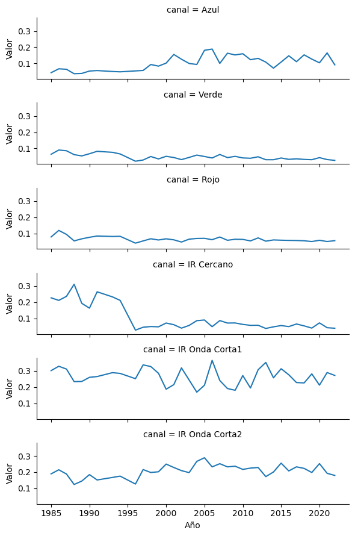

```python
g = sns.FacetGrid(
  d, row="canal",
  height=1.5,
  aspect=4
)
g.map(sns.lineplot, "fecha",  "valor") # , order=PLOTID
g.set(xlabel="Año",ylabel="Valor");
```

### 16. Cáculo del NDVI

```python
dP = d.pivot(index=['fecha',], columns='canal')['valor']
dP['ndvi'] = (dP['IR Cercano'] - dP['Rojo']) / (dP['IR Cercano'] + dP['Rojo'])
dP['ndvi2'] = (dP['IR Onda Corta1'] - dP['Rojo']) / (dP['IR Onda Corta1'] + dP['Rojo'])
dP.head()
```

| canal fecha | Azul | IR Cercano | IR Onda Corta1 | IR Onda Corta2 | Rojo | Verde | ndvi | ndvi2 |
| --- | --- | --- | --- | --- | --- | --- | --- | --- |
| 1985 | 0.042859 | 0.226935 | 0.302396 | 0.189379 | 0.078188 | 0.063890 | 0.487499 | 0.589116 |
| 1986 | 0.066806 | 0.211186 | 0.329191 | 0.214601 | 0.118323 | 0.090012 | 0.281821 | 0.471197 |
| 1987 | 0.063808 | 0.235969 | 0.311810 | 0.188284 | 0.093814 | 0.085506 | 0.431056 | 0.537433 |
| 1988 | 0.036460 | 0.310747 | 0.234407 | 0.123597 | 0.053564 | 0.061477 | 0.705945 | 0.627992 |
| 1989 | 0.038322 | 0.192854 | 0.235307 | 0.144893 | 0.066370 | 0.053679 | 0.487934 | 0.559994 |

### 17. Arreglo de tabla para gráficas

```python
def unpivot(frame):
    N, K = frame.shape
    data = {
        "value": frame.to_numpy().ravel("F"),
        "variable": np.asarray(frame.columns).repeat(N),
        "fecha": np.tile(np.asarray(frame.index), K),
    }
    return pd.DataFrame(data, columns=["fecha","variable", "value"])
dPu = unpivot( dP )
dPu.rename(columns = {'variable':'canal', 'value':'valor'}, inplace = True)
dPu
```

|  | fecha | canal | valor |
| --- | --- | --- | --- |
| 0 | 1985 | Azul | 0.042859 |
| 1 | 1986 | Azul | 0.066806 |
| 2 | 1987 | Azul | 0.063808 |
| 3 | 1988 | Azul | 0.036460 |
| 4 | 1989 | Azul | 0.038322 |
| ... | ... | ... | ... |
| 299 | 2018 | ndvi2 | 0.612530 |
| 300 | 2019 | ndvi2 | 0.700981 |
| 301 | 2020 | ndvi2 | 0.574625 |
| 302 | 2021 | ndvi2 | 0.707526 |
| 303 | 2022 | ndvi2 | 0.663805 |

304 rows × 3 columns

### 18. Gráfica de serie de tiempo por variable

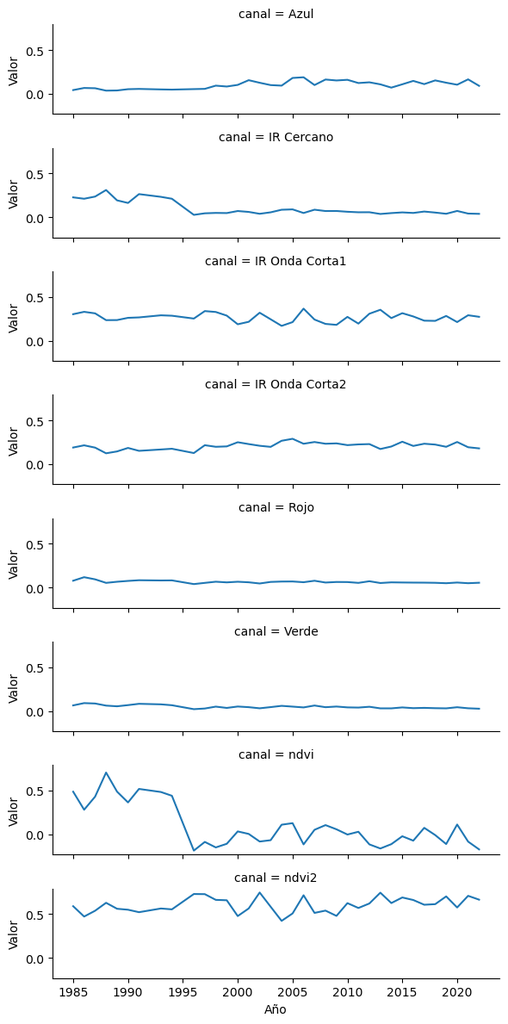

```python
g2 = sns.FacetGrid(
  dPu, row="canal",
  height=1.5,
  aspect=4
)
g2.map(sns.lineplot, "fecha",  "valor") # , order=PLOTID
g2.set(xlabel="Año",ylabel="Valor");
```

### 19. Análisis

En esta fase se recomienda:

- Filtrar por épocas del año de mayor interés (climogramas)
- Describir la serie de tiempo.
- Identificar tendencias, patrones o anomalías.
- Verificar en el inspector las fechas destacadas.
- Escribir reporte señalando posibles causas y conclusiones.
- Emplear otro índicador de cambio (indices, cocientes, etc.).
- Comparar con otro punto de referencia, donde no se detecte cambios.

### 20. Referencias

| JRC | ESRI | Artículo 1 | Artículo 2 |
| --- | --- | --- | --- |
| [1: Python package for near real time detection of change in spatio-temporal datasets](https://github.com/ec-jrc/nrt) | [ArcGis](https://pro.arcgis.com/en/pro-app/latest/tool-reference/image-analyst/how-analyze-changes-using-ccdc-works.htm) | [3: Change Detection Techniques Based on Multispectral Images for Investigating Land Cover Dynamics](https://www.researchgate.net/publication/341839114_Change_Detection_Techniques_Based_on_Multispectr… | [4: Continuous Change Detection and Classification of Land Cover Using All Available Landsat Data](https://www.researchgate.net/publication/260138225_Continuous_Change_Detection_and_Classification_of_… |
| [Documentación](https://nrt.readthedocs.io/en/latest/classes.html) |  | Research Gate | Research Gate |